# Risk Factor Analysis

## Outcome Variable

**Outcome Variable:** ever_stunted

## Predictor Variables

**Intervention Variable:** exclfeed36

**Adjustment Set:**

- arm
- brthmon
- W_mage
- meducyrs
- feducyrs
- hhwealth_quart
- hfoodsec
- W_mhtcm
- W_mwtkg
- W_mbmi
- vagbrth
- W_gagebrth
- W_birthwt
- W_birthlen
- W_nrooms
- W_nchldlt5
- month
- W_parity
- impfloor
- impsan
- safeh20
- delta_W_mage
- delta_meducyrs
- delta_feducyrs
- delta_hhwealth_quart
- delta_hfoodsec
- delta_W_mhtcm
- delta_W_mwtkg
- delta_W_mbmi
- delta_vagbrth
- delta_W_gagebrth
- delta_W_birthwt
- delta_W_birthlen
- delta_W_nrooms
- delta_W_nchldlt5
- delta_month
- delta_W_parity
- delta_impfloor
- delta_impsan
- delta_safeh20

## Stratifying Variables

The analysis was stratified on these variable(s):

- agecat
- studyid
- country

## Data Summary

| agecat | studyid | country | exclfeed36 | ever_stunted | n_cell | n |
| --- | --- | --- | --- | --- | --- | --- |
| 0-24 months (no birth st.) | CMC-V-BCS-2002 | INDIA | 1 | 0 | 1 | 6 |
| 0-24 months (no birth st.) | CMC-V-BCS-2002 | INDIA | 1 | 1 | 5 | 6 |
| 0-24 months (no birth st.) | CMC-V-BCS-2002 | INDIA | 0 | 0 | 0 | 6 |
| 0-24 months (no birth st.) | CMC-V-BCS-2002 | INDIA | 0 | 1 | 0 | 6 |
| 0-24 months (no birth st.) | EE | PAKISTAN | 1 | 0 | 0 | 6 |
| 0-24 months (no birth st.) | EE | PAKISTAN | 1 | 1 | 2 | 6 |
| 0-24 months (no birth st.) | EE | PAKISTAN | 0 | 0 | 2 | 6 |
| 0-24 months (no birth st.) | EE | PAKISTAN | 0 | 1 | 2 | 6 |
| 0-24 months (no birth st.) | GMS-Nepal | NEPAL | 1 | 0 | 132 | 443 |
| 0-24 months (no birth st.) | GMS-Nepal | NEPAL | 1 | 1 | 225 | 443 |
| 0-24 months (no birth st.) | GMS-Nepal | NEPAL | 0 | 0 | 22 | 443 |
| 0-24 months (no birth st.) | GMS-Nepal | NEPAL | 0 | 1 | 64 | 443 |
| 0-24 months (no birth st.) | IRC | INDIA | 1 | 0 | 0 | 3 |
| 0-24 months (no birth st.) | IRC | INDIA | 1 | 1 | 0 | 3 |
| 0-24 months (no birth st.) | IRC | INDIA | 0 | 0 | 1 | 3 |
| 0-24 months (no birth st.) | IRC | INDIA | 0 | 1 | 2 | 3 |
| 0-24 months (no birth st.) | JiVitA-3 | BANGLADESH | 1 | 0 | 4970 | 8764 |
| 0-24 months (no birth st.) | JiVitA-3 | BANGLADESH | 1 | 1 | 1853 | 8764 |
| 0-24 months (no birth st.) | JiVitA-3 | BANGLADESH | 0 | 0 | 1441 | 8764 |
| 0-24 months (no birth st.) | JiVitA-3 | BANGLADESH | 0 | 1 | 500 | 8764 |
| 0-24 months (no birth st.) | JiVitA-4 | BANGLADESH | 1 | 0 | 1495 | 3285 |
| 0-24 months (no birth st.) | JiVitA-4 | BANGLADESH | 1 | 1 | 1083 | 3285 |
| 0-24 months (no birth st.) | JiVitA-4 | BANGLADESH | 0 | 0 | 396 | 3285 |
| 0-24 months (no birth st.) | JiVitA-4 | BANGLADESH | 0 | 1 | 311 | 3285 |
| 0-24 months (no birth st.) | Keneba | GAMBIA | 1 | 0 | 285 | 1798 |
| 0-24 months (no birth st.) | Keneba | GAMBIA | 1 | 1 | 286 | 1798 |
| 0-24 months (no birth st.) | Keneba | GAMBIA | 0 | 0 | 544 | 1798 |
| 0-24 months (no birth st.) | Keneba | GAMBIA | 0 | 1 | 683 | 1798 |
| 0-24 months (no birth st.) | LCNI-5 | MALAWI | 1 | 0 | 18 | 175 |
| 0-24 months (no birth st.) | LCNI-5 | MALAWI | 1 | 1 | 12 | 175 |

[output cut: 174 more lines]

The following strata were considered:

- agecat: 0-24 months (no birth st.), studyid: CMC-V-BCS-2002, country: INDIA
- agecat: 0-24 months (no birth st.), studyid: EE, country: PAKISTAN
- agecat: 0-24 months (no birth st.), studyid: GMS-Nepal, country: NEPAL
- agecat: 0-24 months (no birth st.), studyid: IRC, country: INDIA
- agecat: 0-24 months (no birth st.), studyid: JiVitA-3, country: BANGLADESH
- agecat: 0-24 months (no birth st.), studyid: JiVitA-4, country: BANGLADESH
- agecat: 0-24 months (no birth st.), studyid: Keneba, country: GAMBIA
- agecat: 0-24 months (no birth st.), studyid: LCNI-5, country: MALAWI
- agecat: 0-24 months (no birth st.), studyid: MAL-ED, country: BANGLADESH
- agecat: 0-24 months (no birth st.), studyid: MAL-ED, country: BRAZIL
- agecat: 0-24 months (no birth st.), studyid: MAL-ED, country: INDIA
- agecat: 0-24 months (no birth st.), studyid: MAL-ED, country: NEPAL
- agecat: 0-24 months (no birth st.), studyid: MAL-ED, country: PERU
- agecat: 0-24 months (no birth st.), studyid: MAL-ED, country: SOUTH AFRICA
- agecat: 0-24 months (no birth st.), studyid: MAL-ED, country: TANZANIA, UNITED REPUBLIC OF
- agecat: 0-24 months (no birth st.), studyid: PROVIDE, country: BANGLADESH
- agecat: 0-24 months (no birth st.), studyid: SAS-FoodSuppl, country: INDIA
- agecat: 0-6 months (no birth st.), studyid: CMC-V-BCS-2002, country: INDIA
- agecat: 0-6 months (no birth st.), studyid: EE, country: PAKISTAN
- agecat: 0-6 months (no birth st.), studyid: GMS-Nepal, country: NEPAL
- agecat: 0-6 months (no birth st.), studyid: IRC, country: INDIA
- agecat: 0-6 months (no birth st.), studyid: JiVitA-3, country: BANGLADESH
- agecat: 0-6 months (no birth st.), studyid: JiVitA-4, country: BANGLADESH
- agecat: 0-6 months (no birth st.), studyid: Keneba, country: GAMBIA
- agecat: 0-6 months (no birth st.), studyid: LCNI-5, country: MALAWI
- agecat: 0-6 months (no birth st.), studyid: MAL-ED, country: BANGLADESH
- agecat: 0-6 months (no birth st.), studyid: MAL-ED, country: BRAZIL
- agecat: 0-6 months (no birth st.), studyid: MAL-ED, country: INDIA
- agecat: 0-6 months (no birth st.), studyid: MAL-ED, country: NEPAL
- agecat: 0-6 months (no birth st.), studyid: MAL-ED, country: PERU
- agecat: 0-6 months (no birth st.), studyid: MAL-ED, country: SOUTH AFRICA
- agecat: 0-6 months (no birth st.), studyid: MAL-ED, country: TANZANIA, UNITED REPUBLIC OF
- agecat: 0-6 months (no birth st.), studyid: PROVIDE, country: BANGLADESH
- agecat: 0-6 months (no birth st.), studyid: SAS-FoodSuppl, country: INDIA
- agecat: 6-24 months, studyid: CMC-V-BCS-2002, country: INDIA
- agecat: 6-24 months, studyid: EE, country: PAKISTAN
- agecat: 6-24 months, studyid: GMS-Nepal, country: NEPAL
- agecat: 6-24 months, studyid: IRC, country: INDIA
- agecat: 6-24 months, studyid: JiVitA-3, country: BANGLADESH
- agecat: 6-24 months, studyid: JiVitA-4, country: BANGLADESH
- agecat: 6-24 months, studyid: Keneba, country: GAMBIA
- agecat: 6-24 months, studyid: LCNI-5, country: MALAWI
- agecat: 6-24 months, studyid: MAL-ED, country: BANGLADESH
- agecat: 6-24 months, studyid: MAL-ED, country: BRAZIL
- agecat: 6-24 months, studyid: MAL-ED, country: INDIA
- agecat: 6-24 months, studyid: MAL-ED, country: NEPAL
- agecat: 6-24 months, studyid: MAL-ED, country: PERU
- agecat: 6-24 months, studyid: MAL-ED, country: SOUTH AFRICA
- agecat: 6-24 months, studyid: MAL-ED, country: TANZANIA, UNITED REPUBLIC OF
- agecat: 6-24 months, studyid: PROVIDE, country: BANGLADESH
- agecat: 6-24 months, studyid: SAS-FoodSuppl, country: INDIA

### Dropped Strata

Some strata were dropped due to rare outcomes:

- agecat: 0-24 months (no birth st.), studyid: CMC-V-BCS-2002, country: INDIA
- agecat: 0-24 months (no birth st.), studyid: EE, country: PAKISTAN
- agecat: 0-24 months (no birth st.), studyid: IRC, country: INDIA
- agecat: 0-24 months (no birth st.), studyid: MAL-ED, country: BRAZIL
- agecat: 0-24 months (no birth st.), studyid: MAL-ED, country: INDIA
- agecat: 0-24 months (no birth st.), studyid: MAL-ED, country: NEPAL
- agecat: 0-24 months (no birth st.), studyid: MAL-ED, country: PERU
- agecat: 0-24 months (no birth st.), studyid: MAL-ED, country: SOUTH AFRICA
- agecat: 0-24 months (no birth st.), studyid: MAL-ED, country: TANZANIA, UNITED REPUBLIC OF
- agecat: 0-24 months (no birth st.), studyid: SAS-FoodSuppl, country: INDIA
- agecat: 0-6 months (no birth st.), studyid: CMC-V-BCS-2002, country: INDIA
- agecat: 0-6 months (no birth st.), studyid: EE, country: PAKISTAN
- agecat: 0-6 months (no birth st.), studyid: IRC, country: INDIA
- agecat: 0-6 months (no birth st.), studyid: LCNI-5, country: MALAWI
- agecat: 0-6 months (no birth st.), studyid: MAL-ED, country: BRAZIL
- agecat: 0-6 months (no birth st.), studyid: MAL-ED, country: INDIA
- agecat: 0-6 months (no birth st.), studyid: MAL-ED, country: NEPAL
- agecat: 0-6 months (no birth st.), studyid: MAL-ED, country: PERU
- agecat: 0-6 months (no birth st.), studyid: MAL-ED, country: SOUTH AFRICA
- agecat: 0-6 months (no birth st.), studyid: MAL-ED, country: TANZANIA, UNITED REPUBLIC OF
- agecat: 0-6 months (no birth st.), studyid: SAS-FoodSuppl, country: INDIA
- agecat: 6-24 months, studyid: CMC-V-BCS-2002, country: INDIA
- agecat: 6-24 months, studyid: EE, country: PAKISTAN
- agecat: 6-24 months, studyid: IRC, country: INDIA
- agecat: 6-24 months, studyid: MAL-ED, country: BRAZIL
- agecat: 6-24 months, studyid: MAL-ED, country: INDIA
- agecat: 6-24 months, studyid: MAL-ED, country: NEPAL
- agecat: 6-24 months, studyid: MAL-ED, country: PERU
- agecat: 6-24 months, studyid: MAL-ED, country: SOUTH AFRICA
- agecat: 6-24 months, studyid: MAL-ED, country: TANZANIA, UNITED REPUBLIC OF
- agecat: 6-24 months, studyid: SAS-FoodSuppl, country: INDIA

## Methods Detail

We’re interested in the causal parameters $E[Y_a]$ for all values of $a \in \mathcal{A}$. These parameters represent the mean outcome if, possibly contrary to fact, we intervened to set all units to have $A=a$. Under the randomization and positivity assumptions, these are identified by the statistical parameters $\psi_a=E_W[E_{Y|A,W}(Y|A=a,W)]$. In addition, we’re interested in the mean of $Y$, $E[Y]$ under no intervention (the observed mean). We will estimate these parameters by using SuperLearner to fit the relevant likelihood factors – $E_{Y|A,W}(Y|A=a,W)$ and $p(A=a|W)$, and then updating our likelihood fit using a joint TMLE.

For unadjusted analyses ($W=\{\}$), initial likelihoods were estimated using Lrnr_glm to estimate the simple $E(Y|A)$ and Lrnr_mean to estimate $p(A)$. For adjusted analyses, a small library containing Lrnr_glmnet, Lrnr_xgboost, and Lrnr_mean was used.

Having estimated these parameters, we will then use the delta method to estimate relative risks and attributable risks relative to a prespecified baseline level of $A$.

# Results Detail

## Results Plots

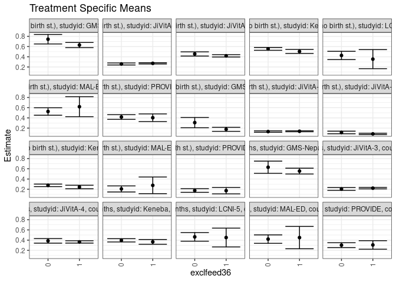

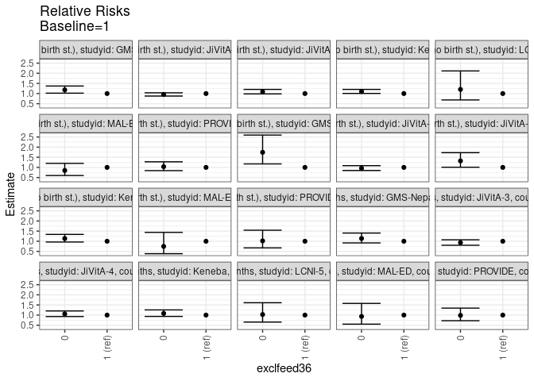

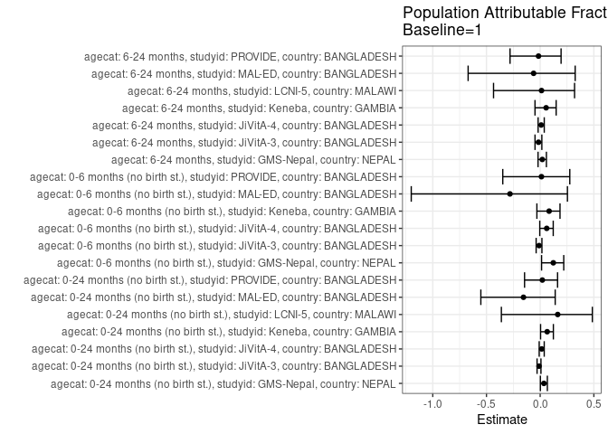

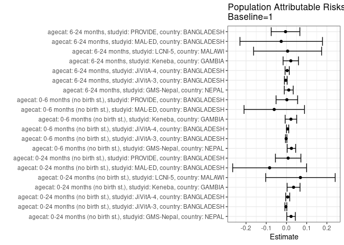

## Results Table

### Parameter: TSM

| agecat | studyid | country | intervention_level | baseline_level | estimate | ci_lower | ci_upper |
| --- | --- | --- | --- | --- | --- | --- | --- |
| 0-24 months (no birth st.) | GMS-Nepal | NEPAL | 1 | NA | 0.6295244 | 0.5793436 | 0.6797052 |
| 0-24 months (no birth st.) | GMS-Nepal | NEPAL | 0 | NA | 0.7440027 | 0.6507154 | 0.8372899 |
| 0-24 months (no birth st.) | JiVitA-3 | BANGLADESH | 1 | NA | 0.2713273 | 0.2590270 | 0.2836277 |
| 0-24 months (no birth st.) | JiVitA-3 | BANGLADESH | 0 | NA | 0.2587825 | 0.2391873 | 0.2783778 |
| 0-24 months (no birth st.) | JiVitA-4 | BANGLADESH | 1 | NA | 0.4181436 | 0.3955555 | 0.4407317 |
| 0-24 months (no birth st.) | JiVitA-4 | BANGLADESH | 0 | NA | 0.4549084 | 0.4141015 | 0.4957154 |
| 0-24 months (no birth st.) | Keneba | GAMBIA | 1 | NA | 0.5037122 | 0.4641354 | 0.5432890 |
| 0-24 months (no birth st.) | Keneba | GAMBIA | 0 | NA | 0.5547289 | 0.5274288 | 0.5820289 |
| 0-24 months (no birth st.) | LCNI-5 | MALAWI | 1 | NA | 0.3537732 | 0.1668341 | 0.5407123 |
| 0-24 months (no birth st.) | LCNI-5 | MALAWI | 0 | NA | 0.4258607 | 0.3448610 | 0.5068604 |
| 0-24 months (no birth st.) | MAL-ED | BANGLADESH | 1 | NA | 0.6191537 | 0.4231650 | 0.8151425 |
| 0-24 months (no birth st.) | MAL-ED | BANGLADESH | 0 | NA | 0.5252260 | 0.4521734 | 0.5982786 |
| 0-24 months (no birth st.) | PROVIDE | BANGLADESH | 1 | NA | 0.4030881 | 0.3283342 | 0.4778421 |
| 0-24 months (no birth st.) | PROVIDE | BANGLADESH | 0 | NA | 0.4171602 | 0.3713006 | 0.4630197 |
| 0-6 months (no birth st.) | GMS-Nepal | NEPAL | 1 | NA | 0.1763162 | 0.1365940 | 0.2160384 |
| 0-6 months (no birth st.) | GMS-Nepal | NEPAL | 0 | NA | 0.3075351 | 0.2069201 | 0.4081501 |
| 0-6 months (no birth st.) | JiVitA-3 | BANGLADESH | 1 | NA | 0.1376820 | 0.1285168 | 0.1468471 |
| 0-6 months (no birth st.) | JiVitA-3 | BANGLADESH | 0 | NA | 0.1320817 | 0.1177982 | 0.1463653 |
| 0-6 months (no birth st.) | JiVitA-4 | BANGLADESH | 1 | NA | 0.0867744 | 0.0731122 | 0.1004366 |
| 0-6 months (no birth st.) | JiVitA-4 | BANGLADESH | 0 | NA | 0.1144554 | 0.0890579 | 0.1398529 |
| 0-6 months (no birth st.) | Keneba | GAMBIA | 1 | NA | 0.2431592 | 0.2085300 | 0.2777884 |
| 0-6 months (no birth st.) | Keneba | GAMBIA | 0 | NA | 0.2759120 | 0.2513001 | 0.3005238 |
| 0-6 months (no birth st.) | MAL-ED | BANGLADESH | 1 | NA | 0.2758621 | 0.1128022 | 0.4389220 |
| 0-6 months (no birth st.) | MAL-ED | BANGLADESH | 0 | NA | 0.2055556 | 0.1463790 | 0.2647321 |
| 0-6 months (no birth st.) | PROVIDE | BANGLADESH | 1 | NA | 0.1715399 | 0.1094100 | 0.2336697 |
| 0-6 months (no birth st.) | PROVIDE | BANGLADESH | 0 | NA | 0.1746741 | 0.1387621 | 0.2105860 |
| 6-24 months | GMS-Nepal | NEPAL | 1 | NA | 0.5552876 | 0.4984330 | 0.6121422 |
| 6-24 months | GMS-Nepal | NEPAL | 0 | NA | 0.6307950 | 0.5114302 | 0.7501599 |
| 6-24 months | JiVitA-3 | BANGLADESH | 1 | NA | 0.2209112 | 0.2065636 | 0.2352588 |
| 6-24 months | JiVitA-3 | BANGLADESH | 0 | NA | 0.2049990 | 0.1769837 | 0.2330143 |
| 6-24 months | JiVitA-4 | BANGLADESH | 1 | NA | 0.3649092 | 0.3424187 | 0.3873998 |
| 6-24 months | JiVitA-4 | BANGLADESH | 0 | NA | 0.3860988 | 0.3410145 | 0.4311831 |
| 6-24 months | Keneba | GAMBIA | 1 | NA | 0.3661804 | 0.3200158 | 0.4123449 |
| 6-24 months | Keneba | GAMBIA | 0 | NA | 0.3967924 | 0.3645379 | 0.4290470 |
| 6-24 months | LCNI-5 | MALAWI | 1 | NA | 0.4509974 | 0.2666287 | 0.6353661 |
| 6-24 months | LCNI-5 | MALAWI | 0 | NA | 0.4636737 | 0.3788378 | 0.5485097 |
| 6-24 months | MAL-ED | BANGLADESH | 1 | NA | 0.4500000 | 0.2312745 | 0.6687255 |
| 6-24 months | MAL-ED | BANGLADESH | 0 | NA | 0.4202899 | 0.3376733 | 0.5029064 |
| 6-24 months | PROVIDE | BANGLADESH | 1 | NA | 0.3057463 | 0.2224364 | 0.3890562 |
| 6-24 months | PROVIDE | BANGLADESH | 0 | NA | 0.3015865 | 0.2534661 | 0.3497068 |

### Parameter: E(Y)

| agecat | studyid | country | intervention_level | baseline_level | estimate | ci_lower | ci_upper |
| --- | --- | --- | --- | --- | --- | --- | --- |
| 0-24 months (no birth st.) | GMS-Nepal | NEPAL | NA | NA | 0.6523702 | 0.6079743 | 0.6967661 |
| 0-24 months (no birth st.) | JiVitA-3 | BANGLADESH | NA | NA | 0.2684847 | 0.2575491 | 0.2794203 |
| 0-24 months (no birth st.) | JiVitA-4 | BANGLADESH | NA | NA | 0.4243531 | 0.4041458 | 0.4445604 |
| 0-24 months (no birth st.) | Keneba | GAMBIA | NA | NA | 0.5389321 | 0.5158847 | 0.5619796 |
| 0-24 months (no birth st.) | LCNI-5 | MALAWI | NA | NA | 0.4228571 | 0.3494545 | 0.4962598 |
| 0-24 months (no birth st.) | MAL-ED | BANGLADESH | NA | NA | 0.5358852 | 0.4681109 | 0.6036595 |
| 0-24 months (no birth st.) | PROVIDE | BANGLADESH | NA | NA | 0.4114583 | 0.3712361 | 0.4516805 |
| 0-6 months (no birth st.) | GMS-Nepal | NEPAL | NA | NA | 0.2009029 | 0.1635496 | 0.2382563 |
| 0-6 months (no birth st.) | JiVitA-3 | BANGLADESH | NA | NA | 0.1362858 | 0.1283472 | 0.1442245 |
| 0-6 months (no birth st.) | JiVitA-4 | BANGLADESH | NA | NA | 0.0924163 | 0.0803439 | 0.1044888 |
| 0-6 months (no birth st.) | Keneba | GAMBIA | NA | NA | 0.2652948 | 0.2448823 | 0.2857072 |
| 0-6 months (no birth st.) | MAL-ED | BANGLADESH | NA | NA | 0.2153110 | 0.1594513 | 0.2711707 |
| 0-6 months (no birth st.) | PROVIDE | BANGLADESH | NA | NA | 0.1736111 | 0.1426515 | 0.2045707 |
| 6-24 months | GMS-Nepal | NEPAL | NA | NA | 0.5665722 | 0.5148041 | 0.6183404 |
| 6-24 months | JiVitA-3 | BANGLADESH | NA | NA | 0.2175047 | 0.2040809 | 0.2309284 |
| 6-24 months | JiVitA-4 | BANGLADESH | NA | NA | 0.3685446 | 0.3480535 | 0.3890357 |
| 6-24 months | Keneba | GAMBIA | NA | NA | 0.3877069 | 0.3608893 | 0.4145245 |
| 6-24 months | LCNI-5 | MALAWI | NA | NA | 0.4567901 | 0.3798457 | 0.5337346 |
| 6-24 months | MAL-ED | BANGLADESH | NA | NA | 0.4240506 | 0.3467471 | 0.5013542 |
| 6-24 months | PROVIDE | BANGLADESH | NA | NA | 0.3010989 | 0.2589018 | 0.3432960 |

### Parameter: RR

| agecat | studyid | country | intervention_level | baseline_level | estimate | ci_lower | ci_upper |
| --- | --- | --- | --- | --- | --- | --- | --- |
| 0-24 months (no birth st.) | GMS-Nepal | NEPAL | 1 | 1 | 1.0000000 | 1.0000000 | 1.000000 |
| 0-24 months (no birth st.) | GMS-Nepal | NEPAL | 0 | 1 | 1.1818488 | 1.0185243 | 1.371363 |
| 0-24 months (no birth st.) | JiVitA-3 | BANGLADESH | 1 | 1 | 1.0000000 | 1.0000000 | 1.000000 |
| 0-24 months (no birth st.) | JiVitA-3 | BANGLADESH | 0 | 1 | 0.9537650 | 0.8768844 | 1.037386 |
| 0-24 months (no birth st.) | JiVitA-4 | BANGLADESH | 1 | 1 | 1.0000000 | 1.0000000 | 1.000000 |
| 0-24 months (no birth st.) | JiVitA-4 | BANGLADESH | 0 | 1 | 1.0879239 | 0.9822674 | 1.204945 |
| 0-24 months (no birth st.) | Keneba | GAMBIA | 1 | 1 | 1.0000000 | 1.0000000 | 1.000000 |
| 0-24 months (no birth st.) | Keneba | GAMBIA | 0 | 1 | 1.1012814 | 1.0061660 | 1.205388 |
| 0-24 months (no birth st.) | LCNI-5 | MALAWI | 1 | 1 | 1.0000000 | 1.0000000 | 1.000000 |
| 0-24 months (no birth st.) | LCNI-5 | MALAWI | 0 | 1 | 1.2037675 | 0.6848903 | 2.115749 |
| 0-24 months (no birth st.) | MAL-ED | BANGLADESH | 1 | 1 | 1.0000000 | 1.0000000 | 1.000000 |
| 0-24 months (no birth st.) | MAL-ED | BANGLADESH | 0 | 1 | 0.8482966 | 0.6001381 | 1.199069 |
| 0-24 months (no birth st.) | PROVIDE | BANGLADESH | 1 | 1 | 1.0000000 | 1.0000000 | 1.000000 |
| 0-24 months (no birth st.) | PROVIDE | BANGLADESH | 0 | 1 | 1.0349106 | 0.8400682 | 1.274944 |
| 0-6 months (no birth st.) | GMS-Nepal | NEPAL | 1 | 1 | 1.0000000 | 1.0000000 | 1.000000 |
| 0-6 months (no birth st.) | GMS-Nepal | NEPAL | 0 | 1 | 1.7442245 | 1.1723911 | 2.594970 |
| 0-6 months (no birth st.) | JiVitA-3 | BANGLADESH | 1 | 1 | 1.0000000 | 1.0000000 | 1.000000 |
| 0-6 months (no birth st.) | JiVitA-3 | BANGLADESH | 0 | 1 | 0.9593248 | 0.8470584 | 1.086471 |
| 0-6 months (no birth st.) | JiVitA-4 | BANGLADESH | 1 | 1 | 1.0000000 | 1.0000000 | 1.000000 |
| 0-6 months (no birth st.) | JiVitA-4 | BANGLADESH | 0 | 1 | 1.3189995 | 1.0075173 | 1.726779 |
| 0-6 months (no birth st.) | Keneba | GAMBIA | 1 | 1 | 1.0000000 | 1.0000000 | 1.000000 |
| 0-6 months (no birth st.) | Keneba | GAMBIA | 0 | 1 | 1.1346967 | 0.9622133 | 1.338099 |
| 0-6 months (no birth st.) | MAL-ED | BANGLADESH | 1 | 1 | 1.0000000 | 1.0000000 | 1.000000 |
| 0-6 months (no birth st.) | MAL-ED | BANGLADESH | 0 | 1 | 0.7451389 | 0.3861012 | 1.438048 |
| 0-6 months (no birth st.) | PROVIDE | BANGLADESH | 1 | 1 | 1.0000000 | 1.0000000 | 1.000000 |
| 0-6 months (no birth st.) | PROVIDE | BANGLADESH | 0 | 1 | 1.0182709 | 0.6717091 | 1.543638 |
| 6-24 months | GMS-Nepal | NEPAL | 1 | 1 | 1.0000000 | 1.0000000 | 1.000000 |
| 6-24 months | GMS-Nepal | NEPAL | 0 | 1 | 1.1359789 | 0.9184064 | 1.405095 |
| 6-24 months | JiVitA-3 | BANGLADESH | 1 | 1 | 1.0000000 | 1.0000000 | 1.000000 |
| 6-24 months | JiVitA-3 | BANGLADESH | 0 | 1 | 0.9279702 | 0.8033963 | 1.071860 |
| 6-24 months | JiVitA-4 | BANGLADESH | 1 | 1 | 1.0000000 | 1.0000000 | 1.000000 |
| 6-24 months | JiVitA-4 | BANGLADESH | 0 | 1 | 1.0580681 | 0.9300170 | 1.203750 |
| 6-24 months | Keneba | GAMBIA | 1 | 1 | 1.0000000 | 1.0000000 | 1.000000 |
| 6-24 months | Keneba | GAMBIA | 0 | 1 | 1.0835983 | 0.9346822 | 1.256240 |
| 6-24 months | LCNI-5 | MALAWI | 1 | 1 | 1.0000000 | 1.0000000 | 1.000000 |
| 6-24 months | LCNI-5 | MALAWI | 0 | 1 | 1.0281073 | 0.6567505 | 1.609447 |
| 6-24 months | MAL-ED | BANGLADESH | 1 | 1 | 1.0000000 | 1.0000000 | 1.000000 |
| 6-24 months | MAL-ED | BANGLADESH | 0 | 1 | 0.9339775 | 0.5528860 | 1.577746 |
| 6-24 months | PROVIDE | BANGLADESH | 1 | 1 | 1.0000000 | 1.0000000 | 1.000000 |
| 6-24 months | PROVIDE | BANGLADESH | 0 | 1 | 0.9863945 | 0.7231078 | 1.345545 |

### Parameter: PAR

| agecat | studyid | country | intervention_level | baseline_level | estimate | ci_lower | ci_upper |
| --- | --- | --- | --- | --- | --- | --- | --- |
| 0-24 months (no birth st.) | GMS-Nepal | NEPAL | 1 | NA | 0.0228458 | 0.0018122 | 0.0438794 |
| 0-24 months (no birth st.) | JiVitA-3 | BANGLADESH | 1 | NA | -0.0028426 | -0.0077136 | 0.0020283 |
| 0-24 months (no birth st.) | JiVitA-4 | BANGLADESH | 1 | NA | 0.0062095 | -0.0037172 | 0.0161362 |
| 0-24 months (no birth st.) | Keneba | GAMBIA | 1 | NA | 0.0352200 | 0.0032052 | 0.0672347 |
| 0-24 months (no birth st.) | LCNI-5 | MALAWI | 1 | NA | 0.0690839 | -0.1026686 | 0.2408364 |
| 0-24 months (no birth st.) | MAL-ED | BANGLADESH | 1 | NA | -0.0832686 | -0.2660059 | 0.0994687 |
| 0-24 months (no birth st.) | PROVIDE | BANGLADESH | 1 | NA | 0.0083702 | -0.0546064 | 0.0713468 |
| 0-6 months (no birth st.) | GMS-Nepal | NEPAL | 1 | NA | 0.0245867 | 0.0036484 | 0.0455250 |
| 0-6 months (no birth st.) | JiVitA-3 | BANGLADESH | 1 | NA | -0.0013961 | -0.0050708 | 0.0022785 |
| 0-6 months (no birth st.) | JiVitA-4 | BANGLADESH | 1 | NA | 0.0056419 | -0.0000519 | 0.0113358 |
| 0-6 months (no birth st.) | Keneba | GAMBIA | 1 | NA | 0.0221356 | -0.0063491 | 0.0506202 |
| 0-6 months (no birth st.) | MAL-ED | BANGLADESH | 1 | NA | -0.0605511 | -0.2099840 | 0.0888819 |
| 0-6 months (no birth st.) | PROVIDE | BANGLADESH | 1 | NA | 0.0020712 | -0.0512228 | 0.0553653 |
| 6-24 months | GMS-Nepal | NEPAL | 1 | NA | 0.0112846 | -0.0106915 | 0.0332607 |
| 6-24 months | JiVitA-3 | BANGLADESH | 1 | NA | -0.0034065 | -0.0102930 | 0.0034799 |
| 6-24 months | JiVitA-4 | BANGLADESH | 1 | NA | 0.0036354 | -0.0069115 | 0.0141823 |
| 6-24 months | Keneba | GAMBIA | 1 | NA | 0.0215265 | -0.0165820 | 0.0596349 |
| 6-24 months | LCNI-5 | MALAWI | 1 | NA | 0.0057927 | -0.1625838 | 0.1741692 |
| 6-24 months | MAL-ED | BANGLADESH | 1 | NA | -0.0259494 | -0.2301676 | 0.1782688 |
| 6-24 months | PROVIDE | BANGLADESH | 1 | NA | -0.0046474 | -0.0755860 | 0.0662912 |

### Parameter: PAF

| agecat | studyid | country | intervention_level | baseline_level | estimate | ci_lower | ci_upper |
| --- | --- | --- | --- | --- | --- | --- | --- |
| 0-24 months (no birth st.) | GMS-Nepal | NEPAL | 1 | NA | 0.0350197 | 0.0020047 | 0.0669425 |
| 0-24 months (no birth st.) | JiVitA-3 | BANGLADESH | 1 | NA | -0.0105877 | -0.0288662 | 0.0073661 |
| 0-24 months (no birth st.) | JiVitA-4 | BANGLADESH | 1 | NA | 0.0146329 | -0.0090562 | 0.0377658 |
| 0-24 months (no birth st.) | Keneba | GAMBIA | 1 | NA | 0.0653514 | 0.0039283 | 0.1229868 |
| 0-24 months (no birth st.) | LCNI-5 | MALAWI | 1 | NA | 0.1633741 | -0.3612056 | 0.4857920 |
| 0-24 months (no birth st.) | MAL-ED | BANGLADESH | 1 | NA | -0.1553851 | -0.5523535 | 0.1400704 |
| 0-24 months (no birth st.) | PROVIDE | BANGLADESH | 1 | NA | 0.0203428 | -0.1453356 | 0.1620550 |
| 0-6 months (no birth st.) | GMS-Nepal | NEPAL | 1 | NA | 0.1223810 | 0.0131205 | 0.2195449 |
| 0-6 months (no birth st.) | JiVitA-3 | BANGLADESH | 1 | NA | -0.0102442 | -0.0374981 | 0.0162937 |
| 0-6 months (no birth st.) | JiVitA-4 | BANGLADESH | 1 | NA | 0.0610490 | -0.0036971 | 0.1216185 |
| 0-6 months (no birth st.) | Keneba | GAMBIA | 1 | NA | 0.0834376 | -0.0305105 | 0.1847860 |
| 0-6 months (no birth st.) | MAL-ED | BANGLADESH | 1 | NA | -0.2812261 | -1.2003633 | 0.2539685 |
| 0-6 months (no birth st.) | PROVIDE | BANGLADESH | 1 | NA | 0.0119303 | -0.3481400 | 0.2758306 |
| 6-24 months | GMS-Nepal | NEPAL | 1 | NA | 0.0199173 | -0.0197504 | 0.0580420 |
| 6-24 months | JiVitA-3 | BANGLADESH | 1 | NA | -0.0156619 | -0.0479541 | 0.0156353 |
| 6-24 months | JiVitA-4 | BANGLADESH | 1 | NA | 0.0098642 | -0.0191435 | 0.0380462 |
| 6-24 months | Keneba | GAMBIA | 1 | NA | 0.0555226 | -0.0480654 | 0.1488722 |
| 6-24 months | LCNI-5 | MALAWI | 1 | NA | 0.0126814 | -0.4341366 | 0.3202892 |
| 6-24 months | MAL-ED | BANGLADESH | 1 | NA | -0.0611940 | -0.6707647 | 0.3259776 |
| 6-24 months | PROVIDE | BANGLADESH | 1 | NA | -0.0154348 | -0.2805620 | 0.1948005 |